# A Sentiment Analysis of Ted Talks

### THE DATA:

The data used in this analysis was found on Kaggle (https://www.kaggle.com/rounakbanik/ted-talks) and presented in two CSV files. The data was originally scraped from the official TED Website.

The context for the data, as provided on Kaggle is as follows:

“These datasets contain information about all audio-video recordings of TED Talks uploaded to the official TED.com website until September 21st, 2017. The TED main dataset contains information about all talks including number of views, number of comments, descriptions, speakers and titles. The TED transcripts dataset contains the transcripts for all talks available on TED.com.”

In the following analysis, we are examining word choice and overall sentiment among Ted Talks with respect to other variables provided in the data.

## Jess’ Analysis

One of the variables provided in the data set is ‘ratings’ which provides a list of various ratings given to the talks provided by the viewers. For each talk, each rating has a number associated with it which represents the number of votes each rating received. I have chosen to define the max rating of each talk as the rating that received the most votes. Before looking at sentiment and word choice in the talks, I will to look at the distribution of max ratings among all ted talks.

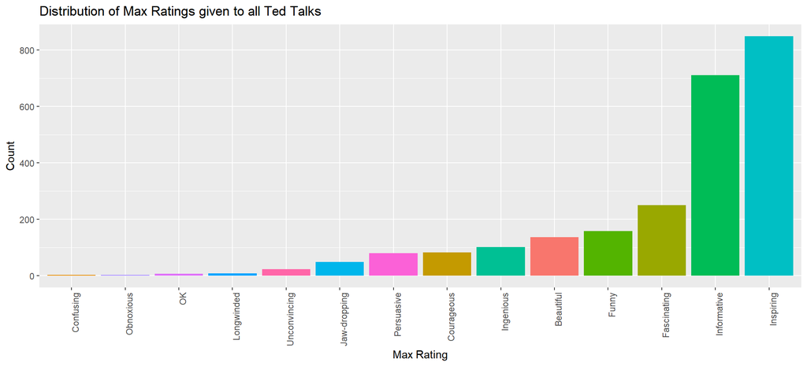

[figure not shown]

The distribution of the top 50 words used in ted talks after removing “like” + “right”

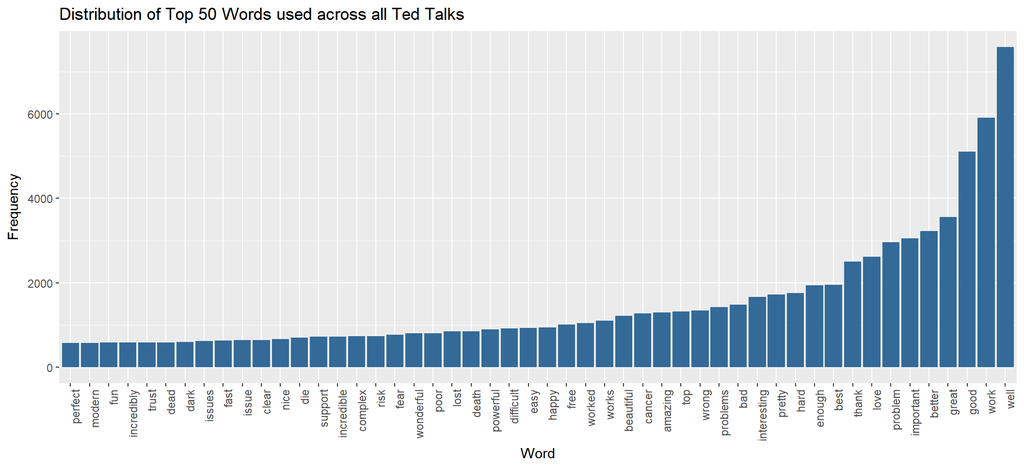

Next, I will use the nrc lexicon to look at the distribution of sentiments, as determined by word choice, among ted talks when grouped by their max rating. The frequency is presented as a proportion here because, as seen above, the number of talks within each max rating group is not uniform.

When looking at the plots below, there does not appear to be any large differences in the distribution among ted talks based on their max rating.

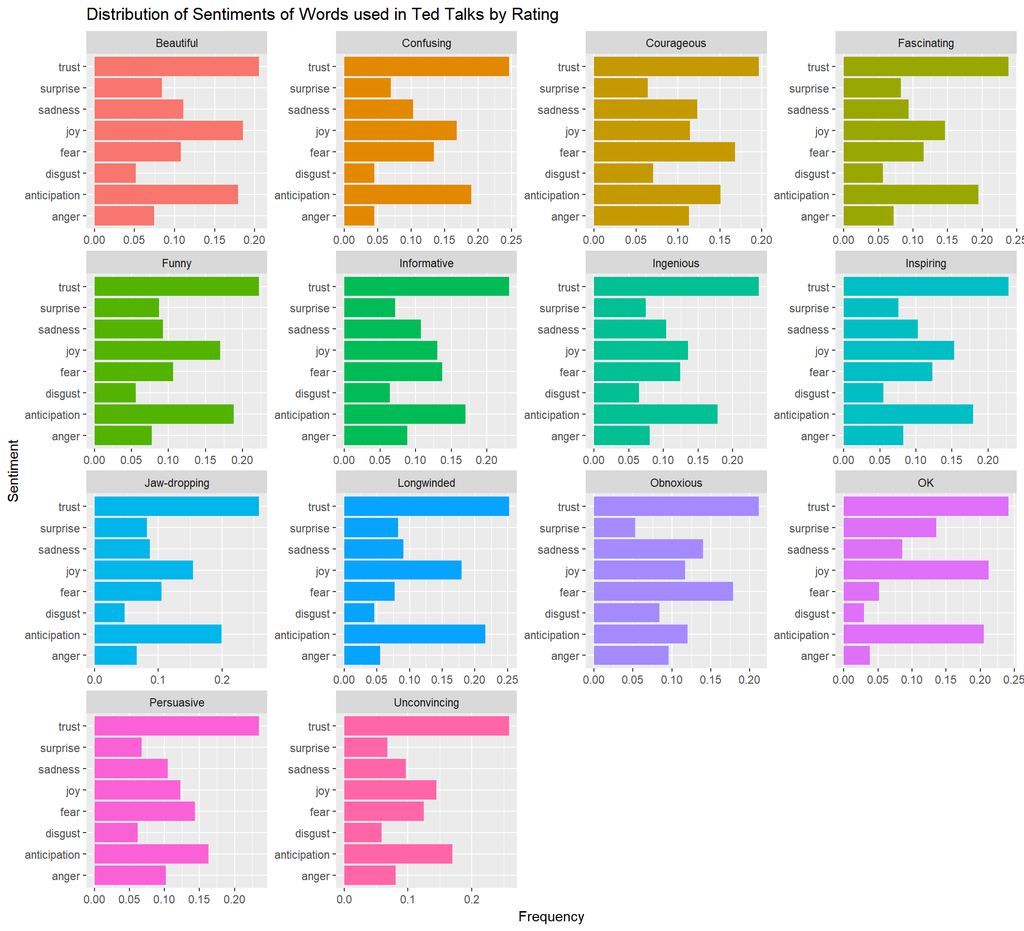

To look more at what may have contributed to the max rating a Ted Talk received from its’ viewers, I will look at the top ten words used in Ted Talks as grouped by max rating. Again the frequencies are presented as proportions to account for differences in sample size among groups.

Some interesting findings shown by these plots are as follows. “Fear” and “death” are among the top 10 words used in talks with a max rating of courageous. “Cancer” is one of the top ten words used in talks with a max rating of informative. Talks with an obnoxious max rating had the most interesting set of top ten words used - “risk”, “complex”, “virus”, “unexpected”, “injury”, “died”. OK talks also had a unique list of top ten words, including “award”, “winner”, and “cave”.

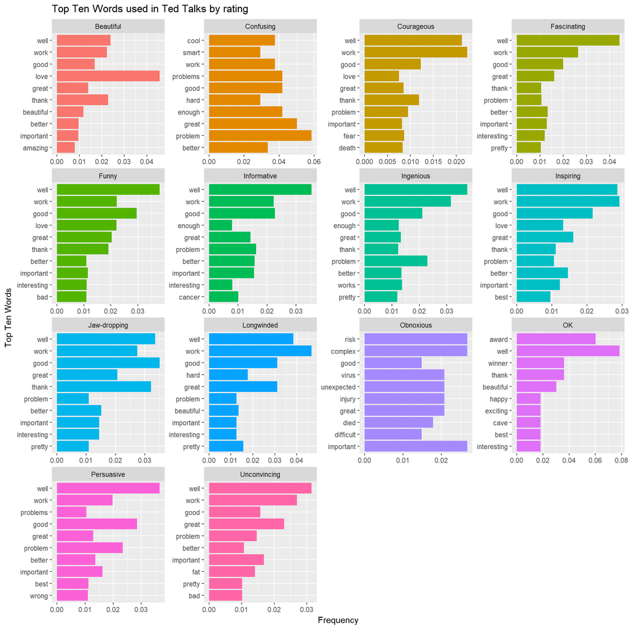

Instead of looking at the distribution of sentiments provided by the nrc lexicon, I will now use the bing lexicon to look at the distribution of positive versus negative Ted Talks are based on their max rating.

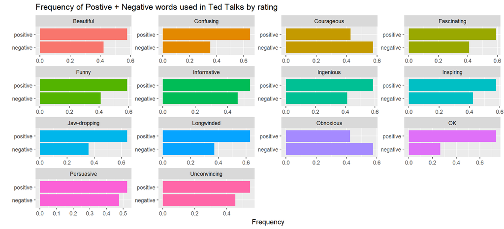

For Ted Talks with a max rating of “Courageous”, “Obnoxious”, or “OK” I will present plots of the top 20 positive and negative words used in those talks.

When the max rating is “Courageous” we see the top 20 negative words used are words that are associated with topics that are difficult to talk about - death, corruption, killed, lost, die, died, dead, pain, suicide, depression.

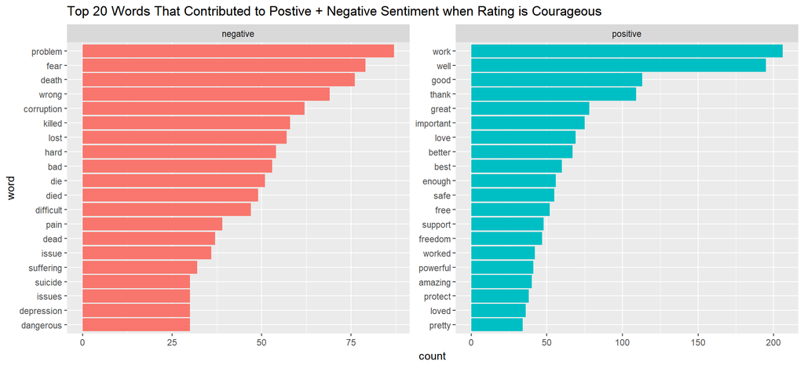

When the max rating is “Obnoxious” - the words or topics that may contribute to the higher negative sentiment are not obvious. We see an interesting group of words in the top 20 most used negative words - virus, neurotic, weird, untouched, epidemic, blunt.

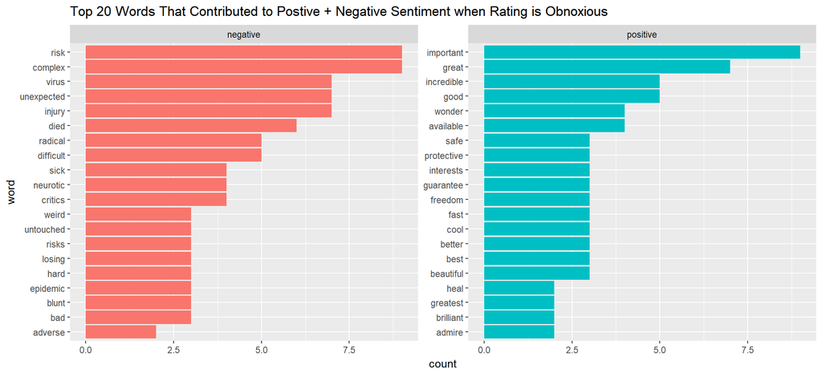

When the max rating is “OK” we see an even less cohesive group of words that contribute to the negative sentiment. The top 20 negative words include - silly, limited, funky, dizzy, died, destruction, cheap, blind, and betray. These words do have a negative connotation but they are not obviously associated with things that are difficult to talk about as seen in the “Courageous” group. This mismatched group of negative words makes sense for a talk that was rated “OK”. Nothing too negative or positive.

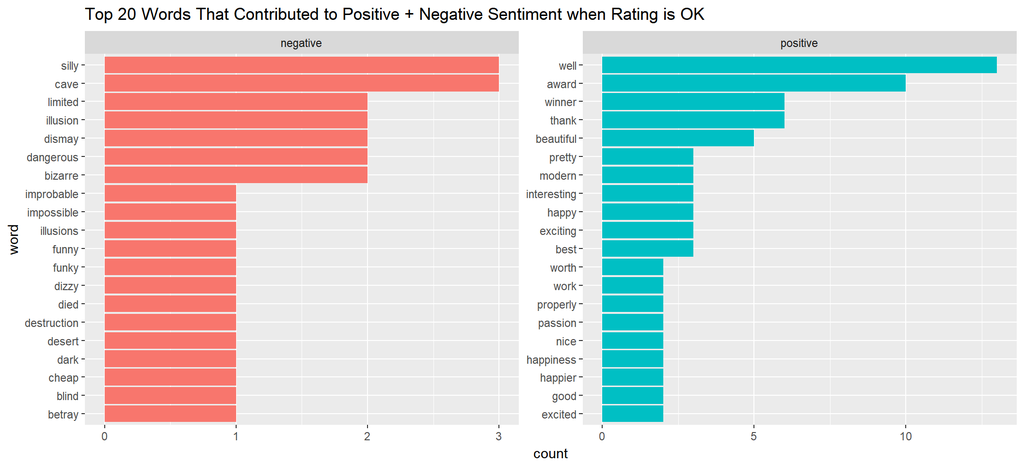

## Blain’s Analysis

### Which talks had the highest proportion of positive words?

Most Positive Talks:

| Name | Word Count | n | p positive |
| --- | --- | --- | --- |
| Onora O’Neill: What we don’t understand about trust | 1380 | 103 | 0.0746377 |
| Ron Gutman: The hidden power of smiling | 1006 | 75 | 0.0745527 |
| Chade-Meng Tan: Everyday compassion at Google | 1731 | 123 | 0.0710572 |
| Richard St. John: 8 secrets of success | 533 | 36 | 0.0675422 |
| Richard St. John: Success is a continuous journey | 671 | 44 | 0.0655738 |
| Jill Shargaa: Please, please, people. Let’s put the ‘awe’ back in ‘awesome’ | 845 | 53 | 0.0627219 |
| Wanuri Kahiu: Fun, fierce and fantastical African art | 649 | 40 | 0.0616333 |
| John Legend: “Redemption Song” | 792 | 48 | 0.0606061 |
| Don Levy: A cinematic journey through visual effects | 567 | 33 | 0.0582011 |
| Mandy Len Catron: A better way to talk about love | 2104 | 122 | 0.0579848 |
| Larry Smith: Why you will fail to have a great career | 2019 | 117 | 0.0579495 |
| Jane McGonigal: Massively multi-player… thumb-wrestling? | 1333 | 77 | 0.0577644 |
| Denis Dutton: A Darwinian theory of beauty | 1901 | 109 | 0.0573382 |
| David Steindl-Rast: Want to be happy? Be grateful | 1788 | 102 | 0.0570470 |
| Einstein the Parrot: A talking, squawking parrot | 973 | 55 | 0.0565262 |
| Jenna McCarthy: What you don’t know about marriage | 1597 | 90 | 0.0563557 |
| Raul Midon: “Peace on Earth” | 599 | 33 | 0.0550918 |
| Michelle Obama: A passionate, personal case for education | 1565 | 86 | 0.0549521 |
| Martin Seligman: The new era of positive psychology | 3235 | 177 | 0.0547141 |
| Dan Dennett: Cute, sexy, sweet, funny | 1049 | 57 | 0.0543375 |

To obtain this chart we filtered presentations that had fewer than 510 words. This filter was chosen to help remove some artistic performances, which we did not want to include in the analysis. However, we see that “John Legend: Redemption Song” still made it through.

Many of the talks featured in the above table are what we would expect. Most have a positive sentiment in their title (such as “The Hidden Power”). Some talks were expected to be positive because of the speaker’s position (for example, Michelle Obama makes it on the list).

### Which words contributed the most often to sentiment scores?

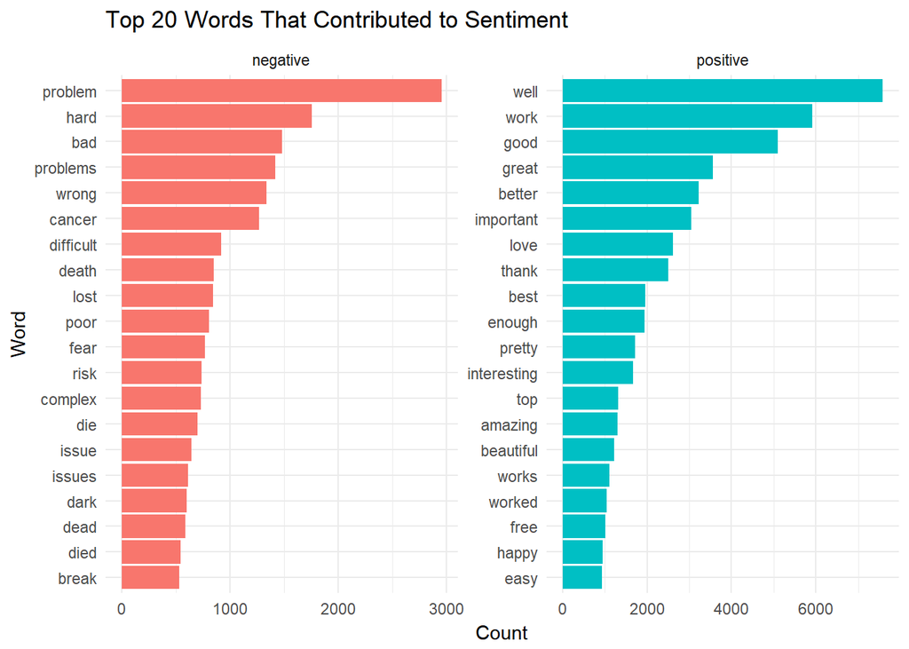

We can see from the chart above that the word “problem” contributed the most toward negative sentiment scores and that the word “well” contributed the most towards a positive score. It is interesting that the word “cancer” appears more times in the talks than “happy.” However, this observation is not suprising when considering the problem solving nature of the TED conference.

### Did sentiment change over time?

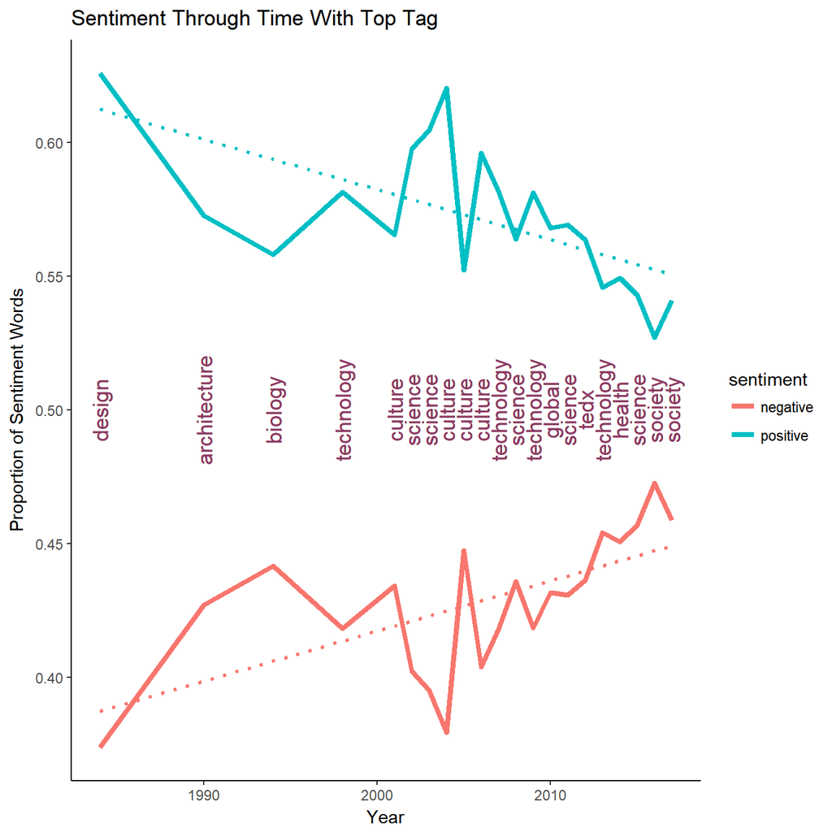

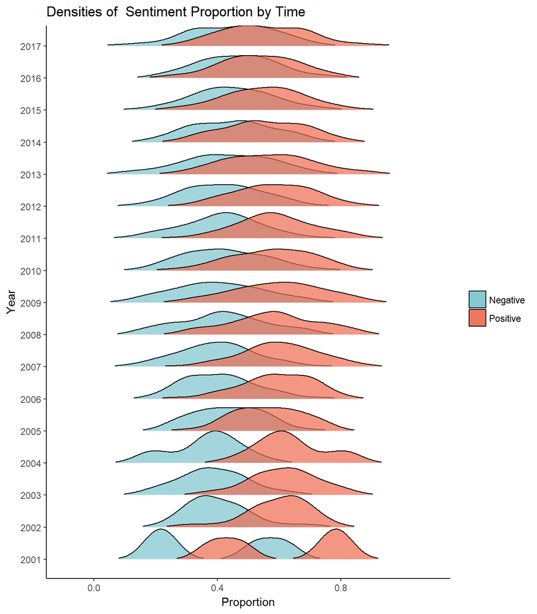

The ridge plot highlights that the proportion of sentiment words is usually higher on average than the proportion of negative words. However, this difference seems to be decreasing over time. The gray areas where the ridgelines overlap represent the number of talks where there was actually a higher proportion of negative words.

### Was there a difference in positive sentiment between talks that were tagged “culture” and talks that were tagged “technology”?

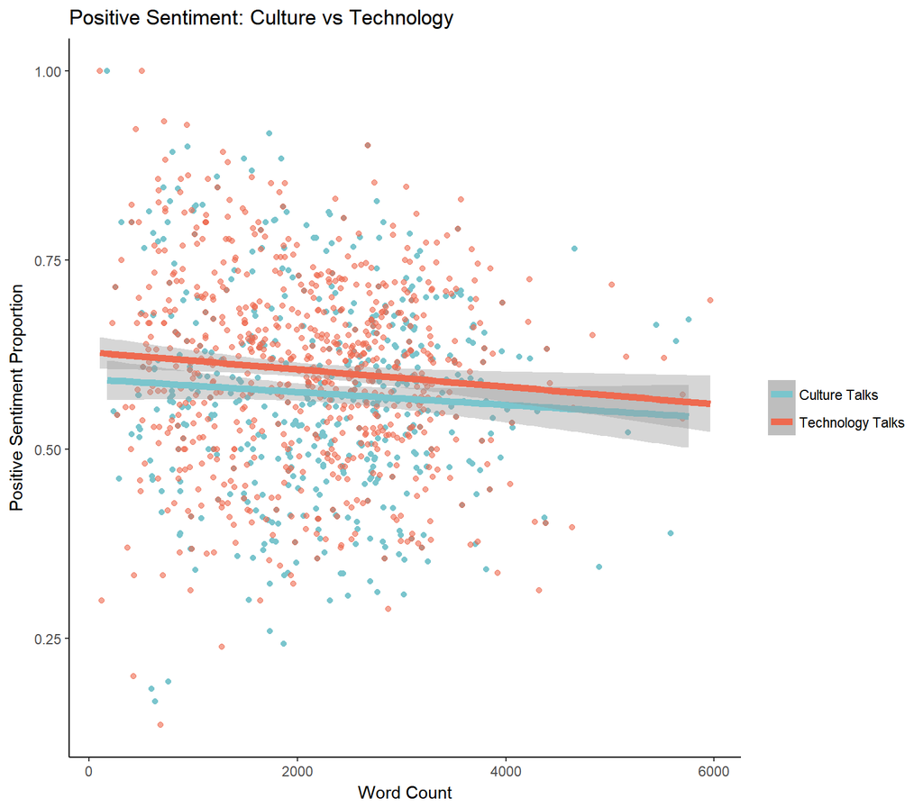

At 95% confidence, there does not seem to be a difference in the proportion of positive sentiment words between culture talks and technology talks. Word count on the X axis would not always be a valid way to compare these proportions, but in this case there is a similar inverse trend. We can also look at the difference in mean positive sentiment word proportion:

| Culture | Technology |
| --- | --- |
| 0.5738392 | 0.6046312 |

### Was there a difference in the trend of positive sentiments between culture and technology talks?

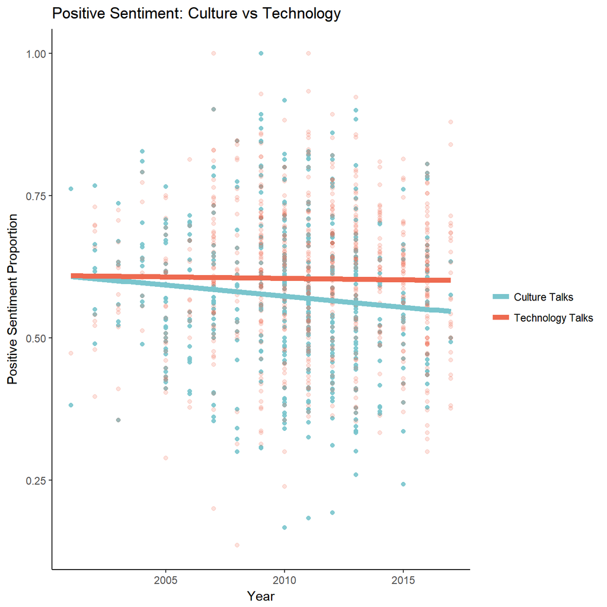

There does appear to be a difference in trends between culture talks and techonolgy talks: culture talks seems to have decreased in positivity whereas positivity in the technology talks has remained relatively constant.